# Análisis exploratorio de la producción de hidrocarburos en Chubut

# Visualización de la producción de petróleo en m3 trabajando con rangos

Se realizaron rangos para obtener una mejor visualización de los datos.

[output not shown]

[output cut: 82 more lines]

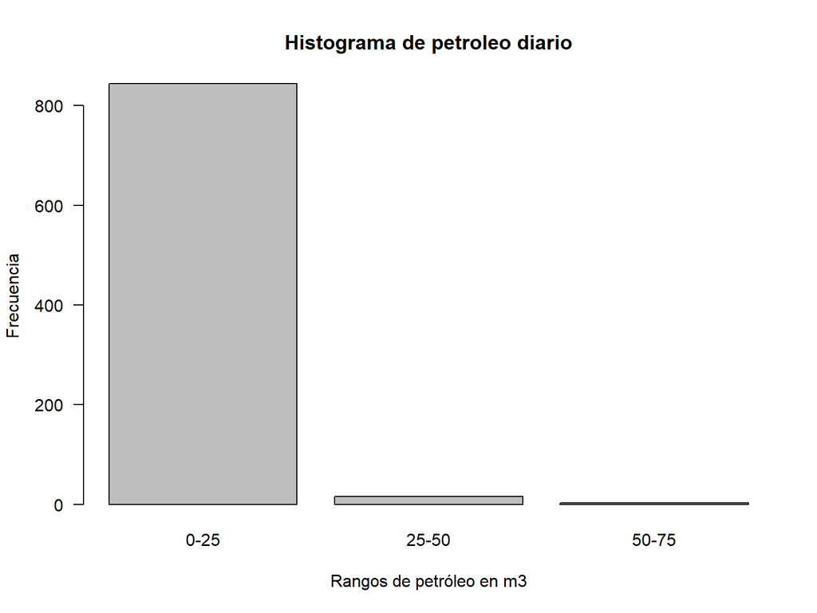

[output not shown]

[output cut: 202 more lines]

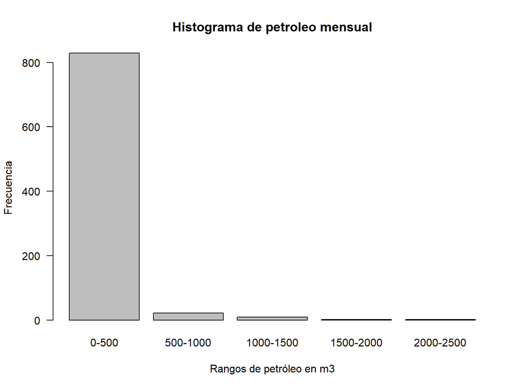

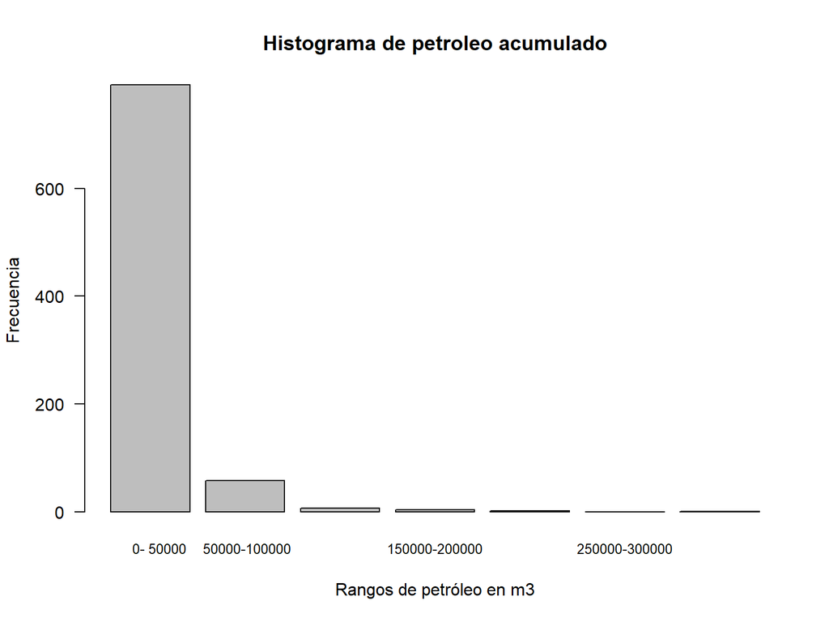

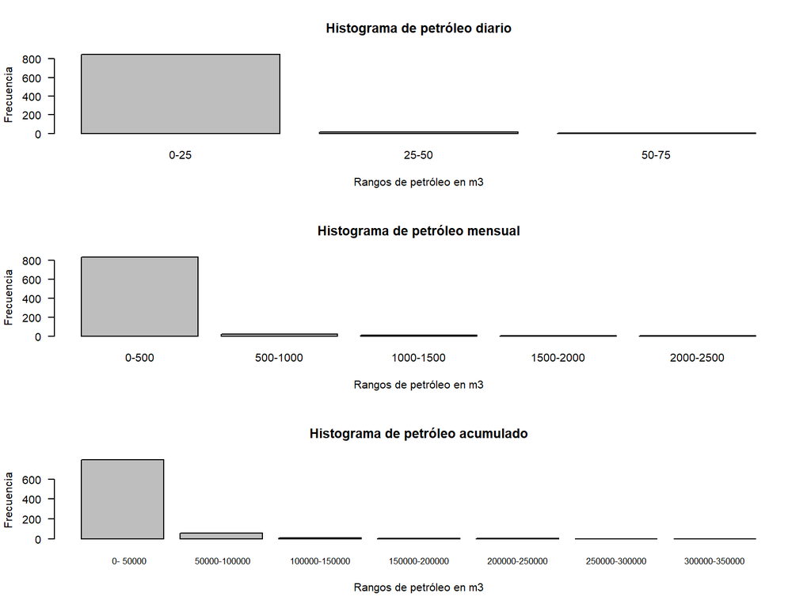

En base al gráfico se sabe que por ejemplo, tenemos mayor cantidad de pozos que producen un rango de 0-500 m3 de petróleo al mes.

# Visualización de la producción de gas en m3 trabajando con rangos

[output not shown]

[output cut: 159 more lines]

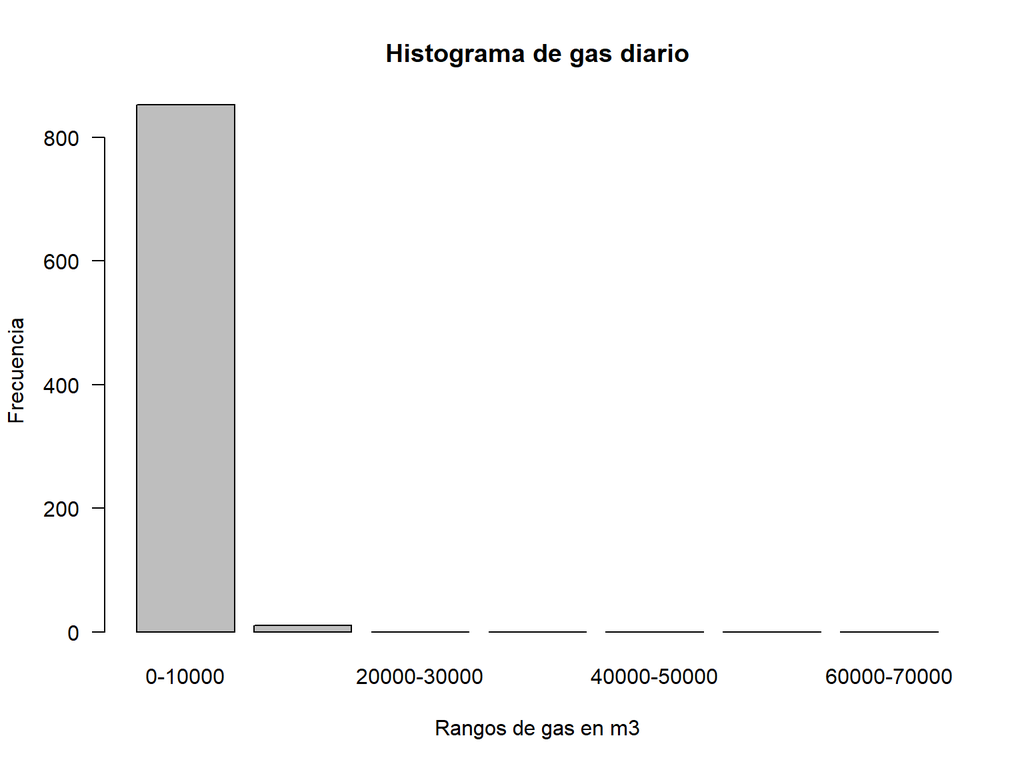

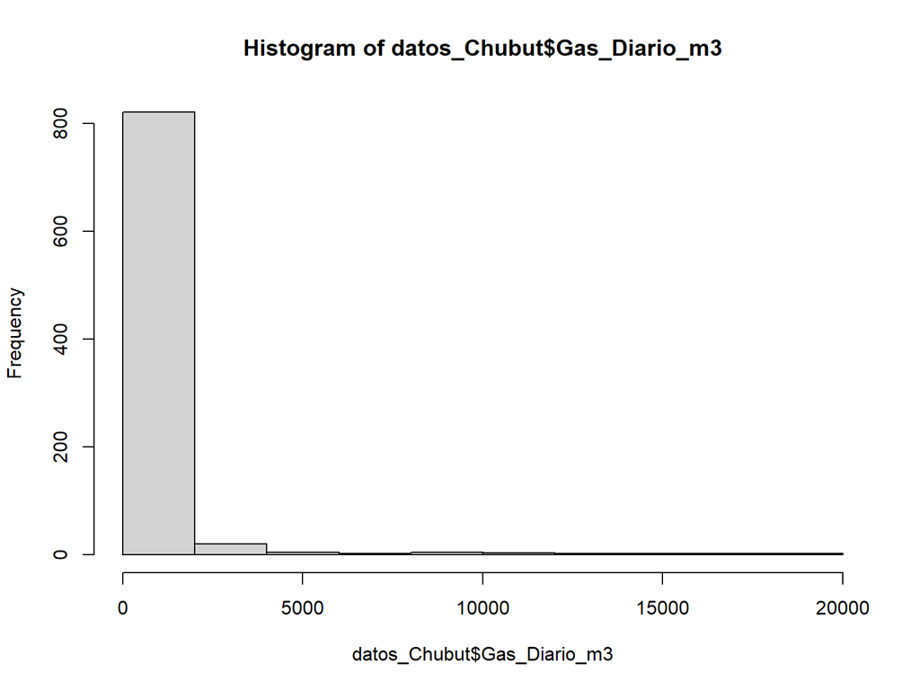

[output not shown]

[output cut: 202 more lines]

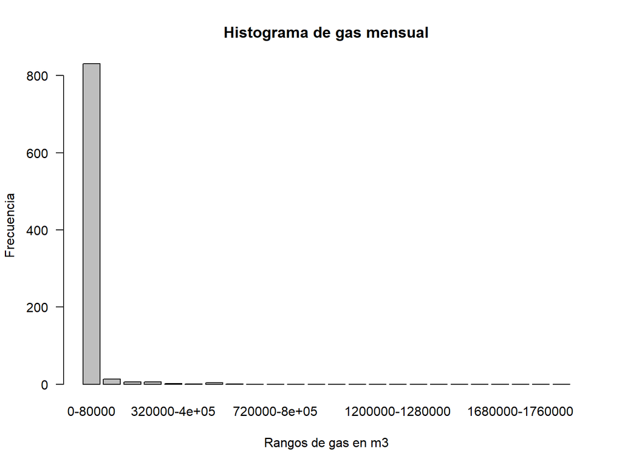

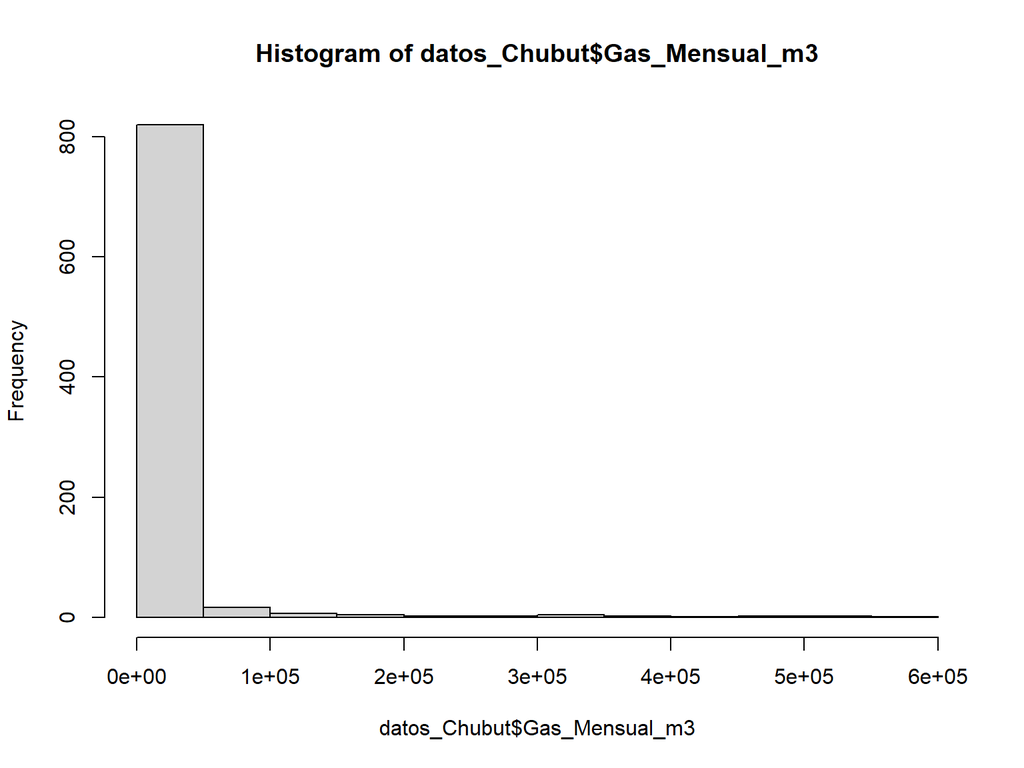

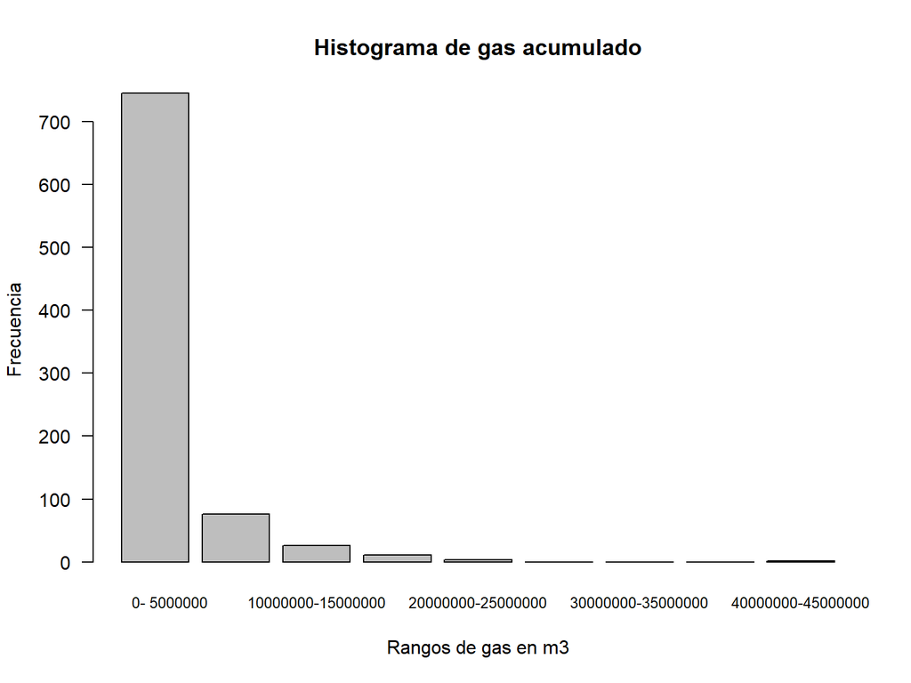

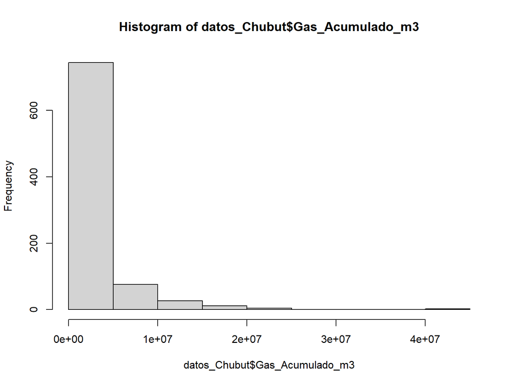

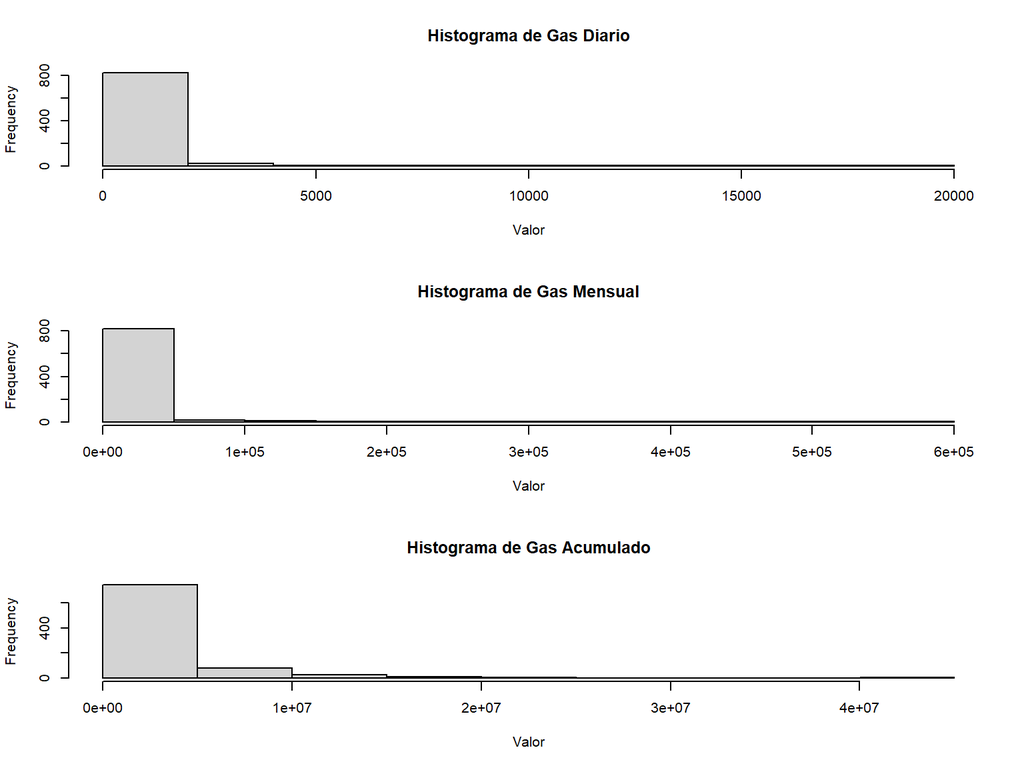

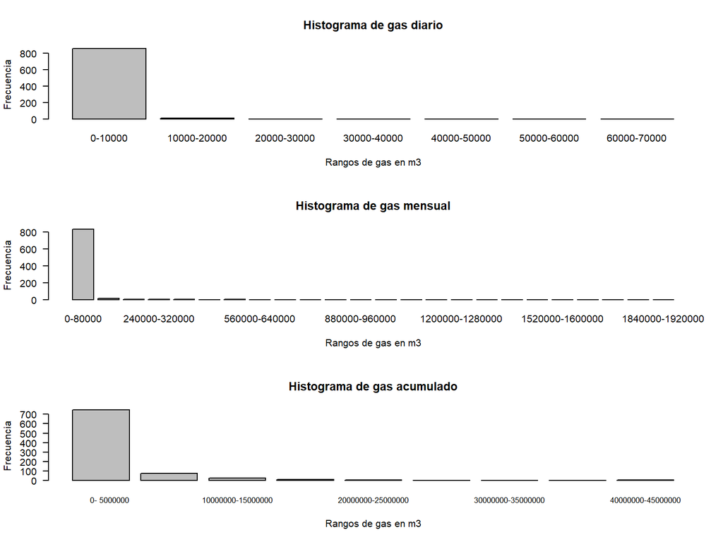

En base a este último gráfico sabemos que por ejemplo, la mayor parte de los pozos producen un rango de 0 a 80000 m3 de gas mensual.

# Función ggplot2

Esta función se aplicó para analizar la cantidad de pozos correspondiente a cada yacimiento en Chubut para la producción de petróleo.

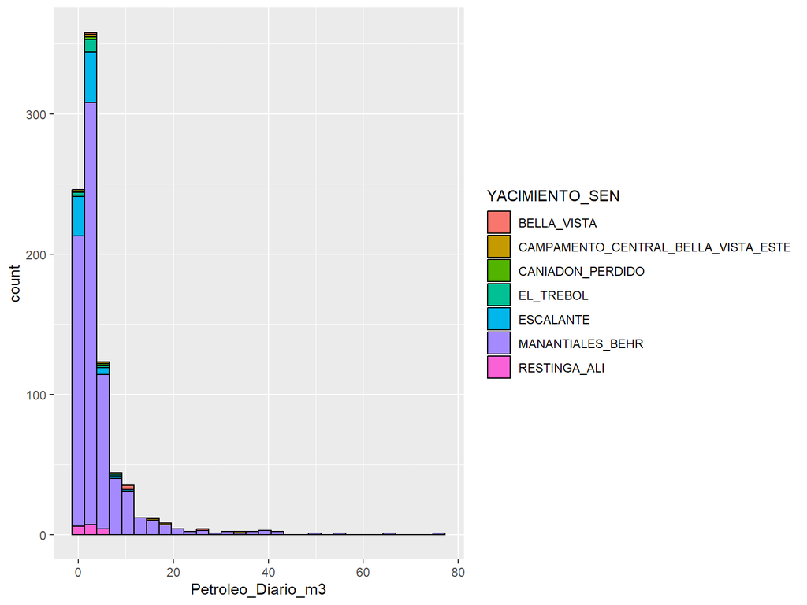

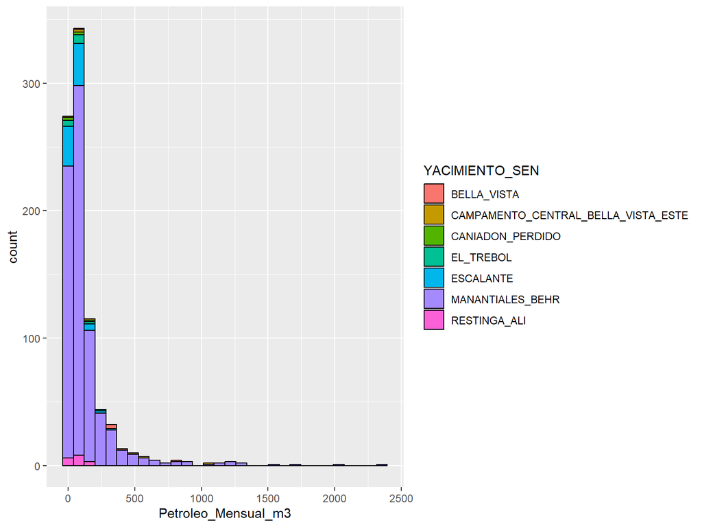

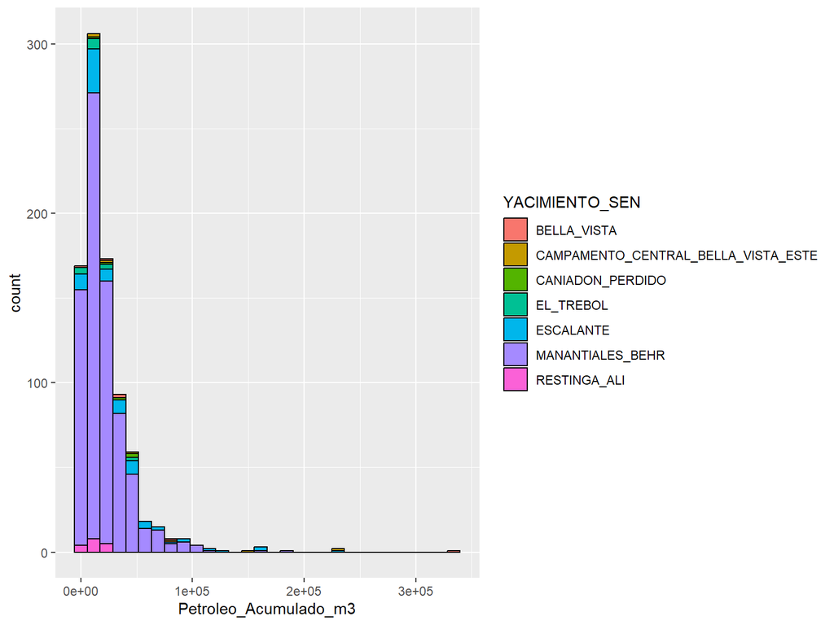

# Función gridExtra

Esta función fue empleada para visualizar los 3 ggplot juntos

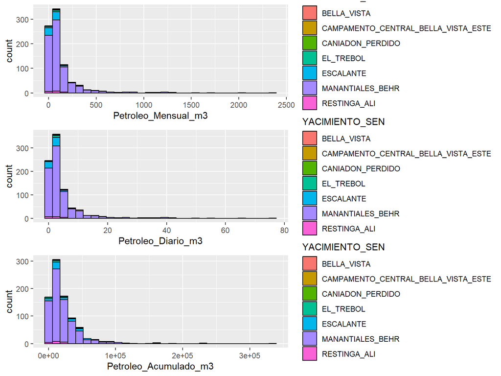

De este gráfico se desprende que por ejemplo, en lo que respeta a la producción de diaria de petróleo aquellos pozos que producen un rango de 0 a 20 m3 pertenecen en su mayoria al yacimiento Manantiales Behr.

# Función Ggplot

La misma función se aplicó para analizar la cantidad de pozos correspondiente a cada yacimiento en Chubut para la producción de Gas.

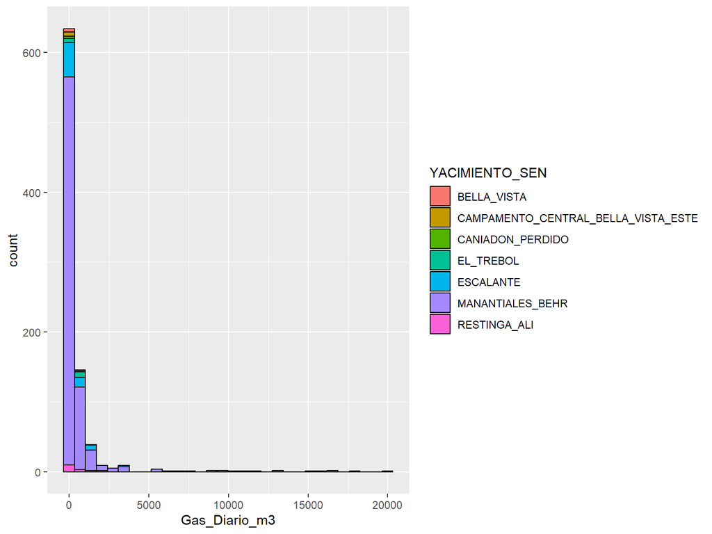

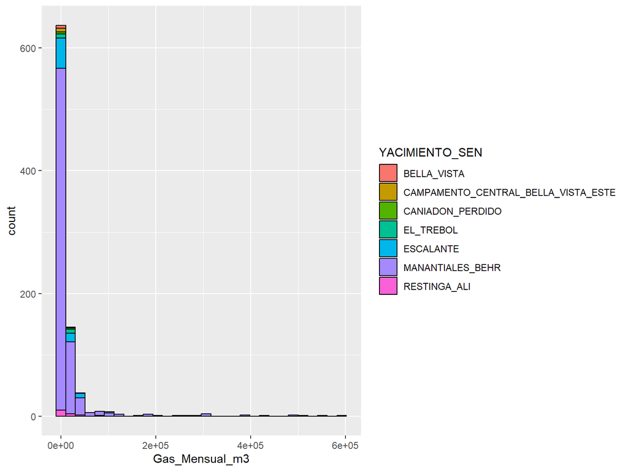

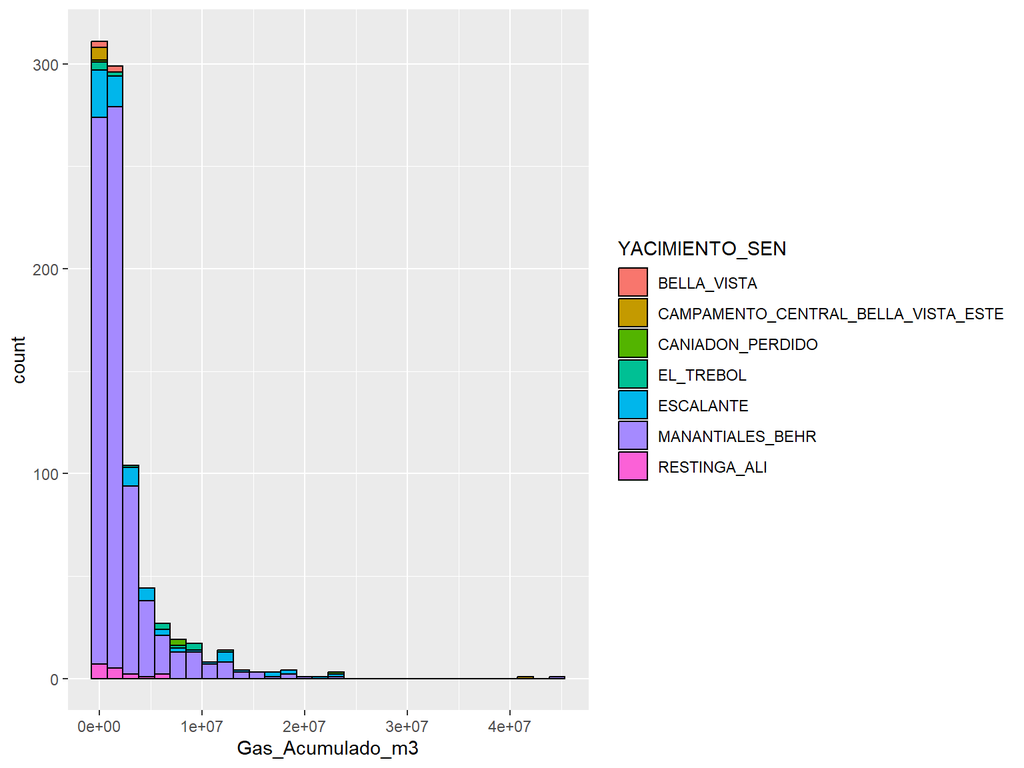

Esta función fue empleada para visualizar los 3 ggplot juntos nuevamente

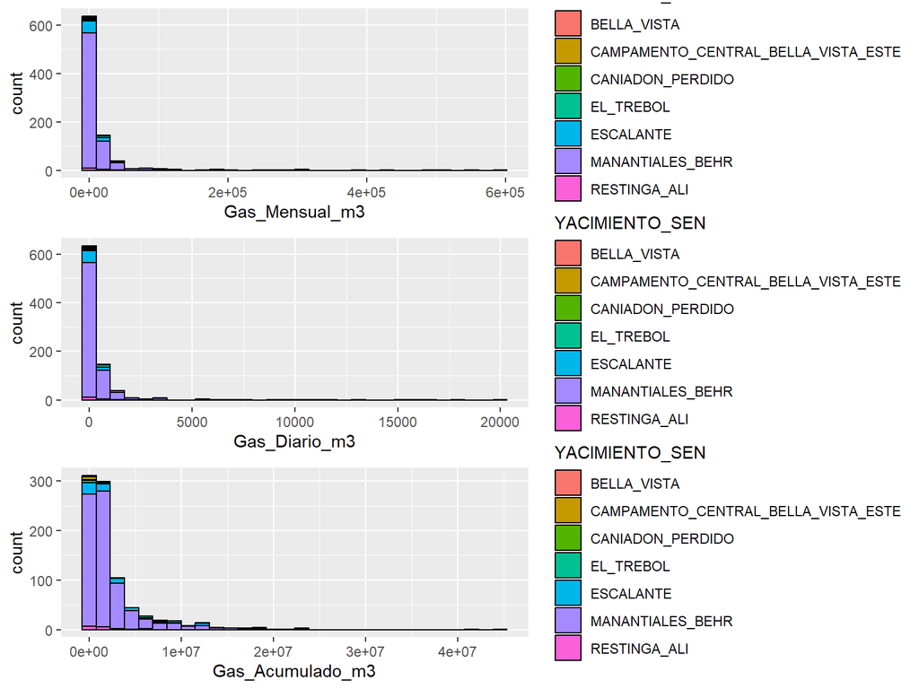

De este gráfico se infiere que después de los pozos del yacimiento Manantiales Behr, los pozos del yacimiento Escalante se ubican en segundo lugar en cuanto a mayor cantidad de pozos de gas en producción diaria, en un rango que va de 0 a 5000 m3.

# Categorización de datos de petroleo mensual en m3

Se intentó dividir los valores de volúmen de la columnas petroleo mensual, gas mensual y agua mensual, del dataset en bajo, medio y alto para trabajar categorías.

[output not shown]

[output cut: 58 more lines]

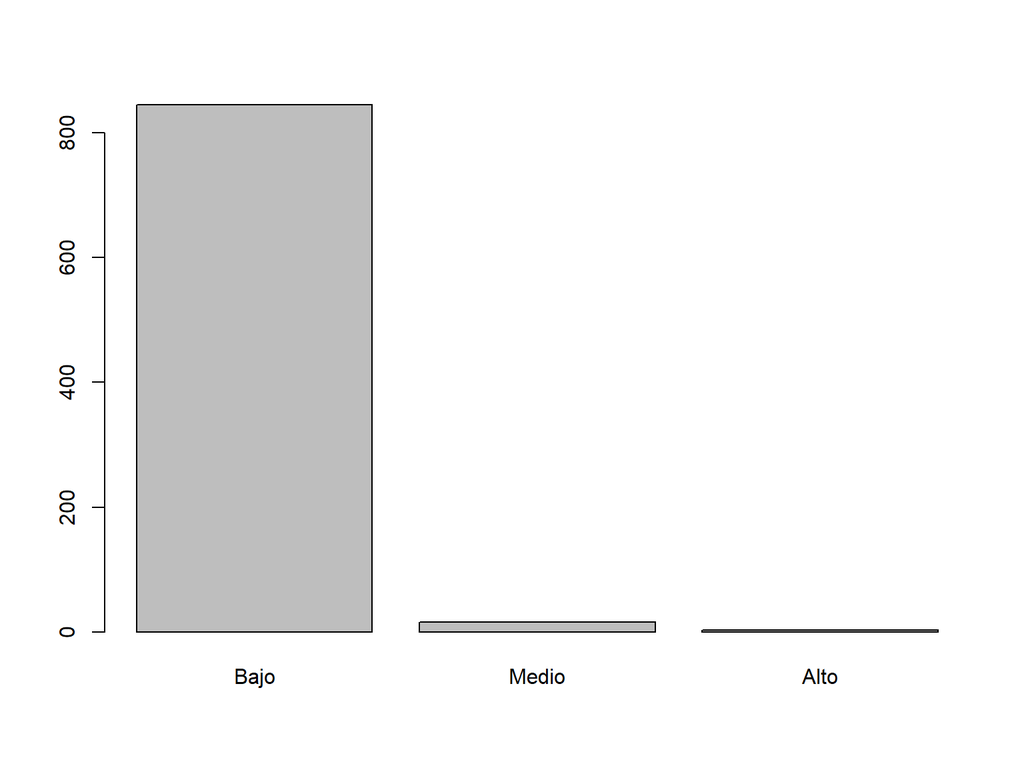

[output not shown]

[output cut: 58 more lines]

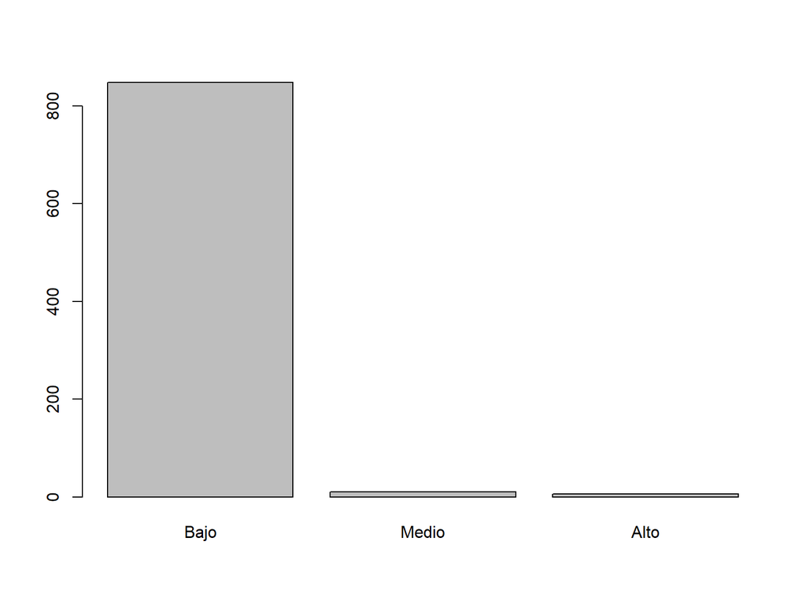

[output not shown]

[output cut: 58 more lines]

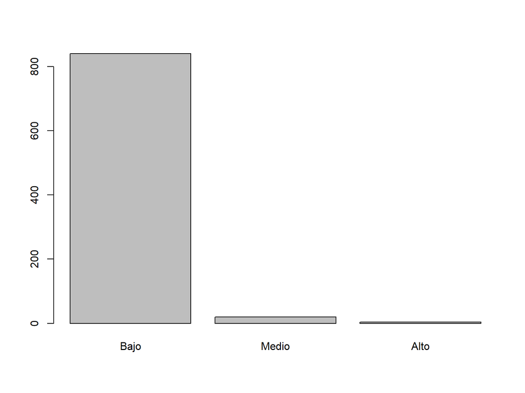

A partir de los gráficos se asume que la mayor parte de los datos expresados en m3 se agrupan en el grupo Bajo, definido por R. Quedando la menor parte de ellos en el grupo Alto.

# Función plot

Se intentó correlacionar datos de gas y petroleo diario en m3

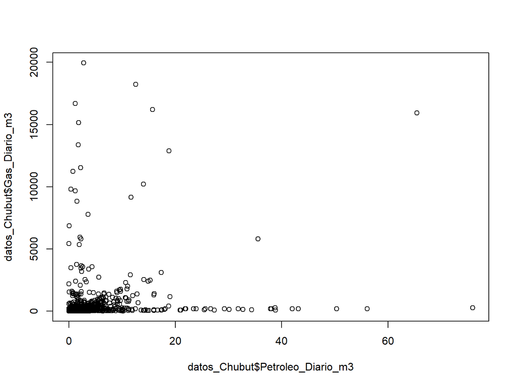

# Función density aplicada a la columna petroleo acumulado del dataset

Se puede notar que tenemos un grupo de datos que se destaca por encima del resto, el cual representa un rango de producción de 0 a 50000 m3.

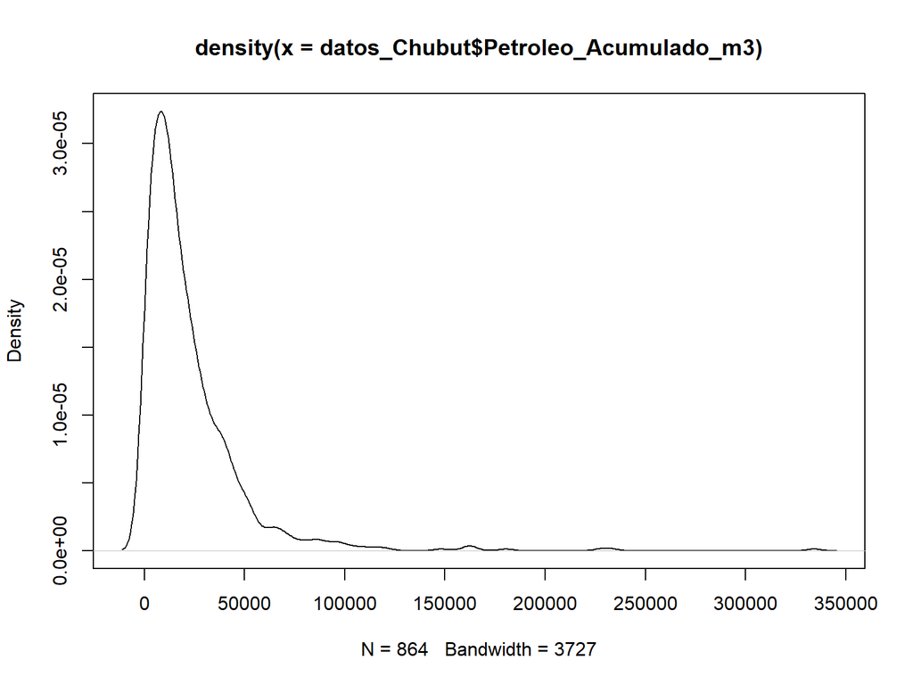

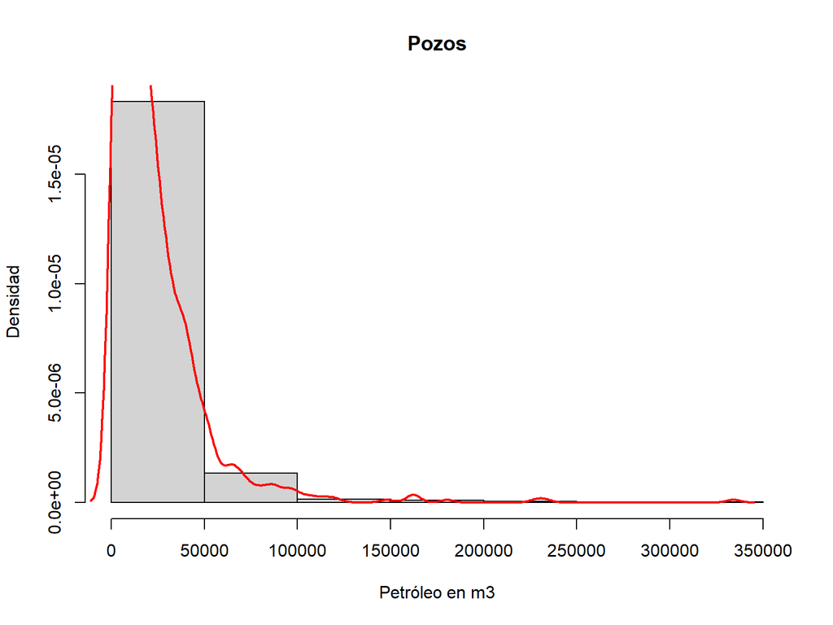

# Función plot para visualizar datos de gas diario, mensual y acumulado.

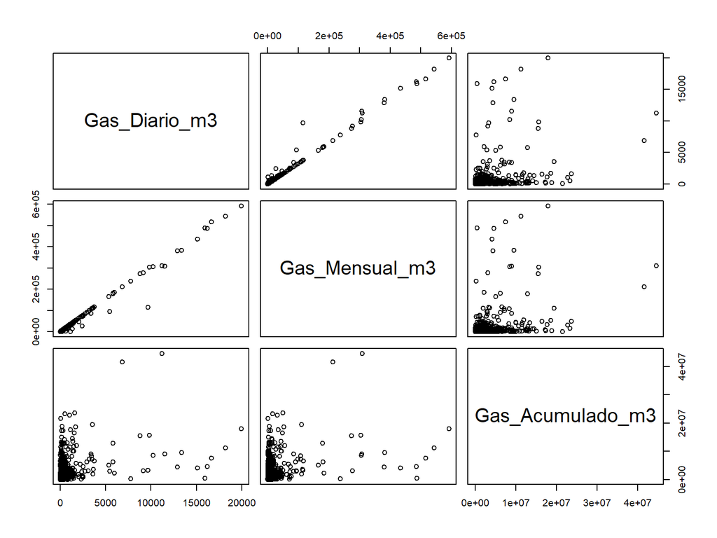

# Función plot para visualizar datos de agua diaria, mensual y acumulada.

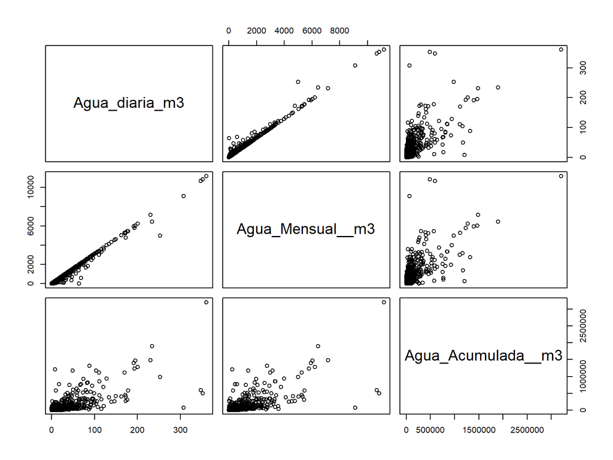

# Función plot para visualizar datos de gas y petróleo acumulado agregando colores

Se observa claramente una mayor concentración de datos sobre el margen inferior izquierdo del gráfico.

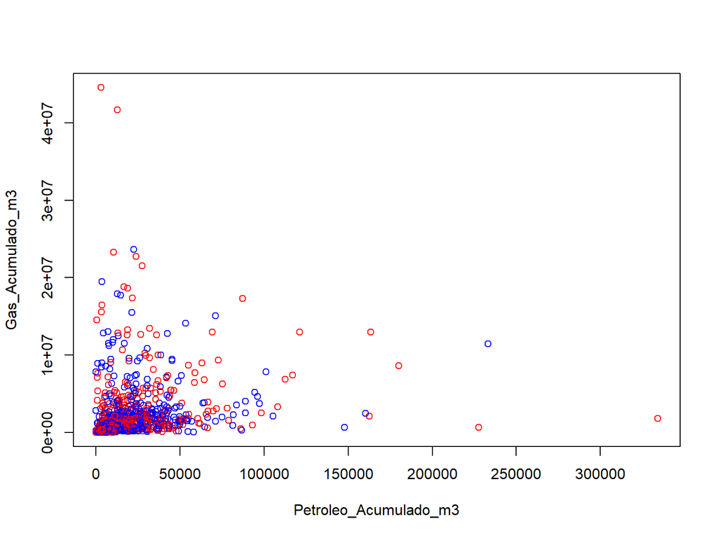

# Categorización de la columna NOMBRE_DE_ESTADO_TOW para saber cuantos pozos están en reserva, abandonados, etc.

```
##
##    AA AAPBP AAPRT    AP  APRT   CEP    EE   EER    ER  ERDG     O     P   PAR
##   475     8     8  3328    10     5    90    64     1    53     3  2361    12
##   PEM   PZA   RRS    VT
##     5     3  1543     2
```

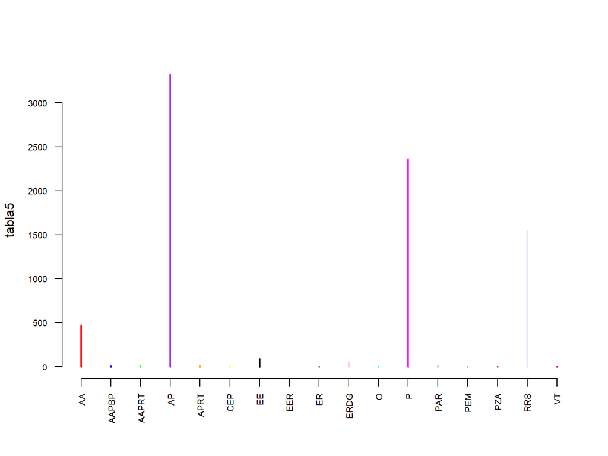

# Función sort

Esta función fue útil para ordenar los volúmenes de pozos de petróleo mensual de menor a mayor

```
## # A tibble: 864 × 18
##    YACIMIENTO_SEN               YAC_SEN FORMACION NOMBRE_CORTO NOM_DE_ESTADO_TOW
##    <chr>                          <dbl> <chr>     <chr>        <chr>
##  1 BELLA_VISTA                        1 GRUPO_CH… BVd_553      Produciendo
##  2 BELLA_VISTA                        1 GRUPO_CH… BV_469       Produciendo
##  3 BELLA_VISTA                        1 GRUPO_CH… BV_526(d)(I) Produciendo
##  4 BELLA_VISTA                        1 GRUPO_CH… BV_576(d)    Produciendo
##  5 BELLA_VISTA                        1 GRUPO_CH… BV_577(d)    Produciendo
##  6 BELLA_VISTA                        1 GRUPO_CH… BV_578(d)    Produciendo
##  7 CAMPAMENTO_CENTRAL_BELLA_VI…       2 GRUPO_CH… BVd_540      Produciendo
##  8 CAMPAMENTO_CENTRAL_BELLA_VI…       2 GRUPO_CH… BVd_544      Produciendo
##  9 CAMPAMENTO_CENTRAL_BELLA_VI…       2 GRUPO_CH… BVd_556      Produciendo
## 10 CAMPAMENTO_CENTRAL_BELLA_VI…       2 GRUPO_CH… BVd_557      Produciendo
## # ℹ 854 more rows
## # ℹ 13 more variables: NOMBRE_DE_ESTADO_TOW <chr>, Petroleo_Diario_m3 <dbl>,
## #   Petroleo_Mensual_m3 <dbl>, Petroleo_Acumulado_m3 <dbl>,
## #   Gas_Diario_m3 <dbl>, Gas_Mensual_m3 <dbl>, Gas_Acumulado_m3 <dbl>,
## #   Agua_diaria_m3 <dbl>, Agua_Mensual__m3 <dbl>, Agua_Acumulada__m3 <dbl>,
## #   TEF_de_Produccion_dias <dbl>, TEF_de_Produccion_Acum <dbl>, GOR <dbl>
```

```
##   [1]    0.125    0.140    0.143    0.146    0.151    0.411    0.430    0.467
##   [9]    0.554    0.580    0.598    0.678    0.681    0.905    0.924    1.303
##  [17]    1.440    1.479    1.527    1.802    2.018    2.882    3.163    3.196
##  [25]    3.751    4.186    4.371    4.376    5.535    5.698    5.724    5.757
##  [33]    6.095    6.672    6.867    7.254    7.346    7.665    8.334    8.587
##  [41]    9.138    9.172    9.746   10.085   10.127   10.254   10.524   10.934
##  [49]   11.244   11.386   11.684   11.796   11.849   12.126   12.135   12.150
##  [57]   12.364   12.421   12.808   13.195   13.325   13.684   13.734   13.810
##  [65]   13.821   14.018   14.148   14.274   14.430   14.468   14.475   14.569
##  [73]   15.234   15.283   15.305   15.327   15.329   15.544   15.646   15.661
##  [81]   15.670   15.957   16.248   16.314   16.363   16.675   16.904   16.969
##  [89]   17.147   17.212   17.358   17.643   17.655   17.766   17.987   18.001
##  [97]   18.100   18.385   18.404   18.467   18.781   18.954   18.957   19.081
## [105]   19.208   19.283   19.409   19.522   19.588   19.654   19.665   19.690
## [113]   19.749   19.759   19.936   19.949   20.121   20.262   20.311   20.317
```

[output cut: 93 more lines]

# Función length

Fue útil para saber el tamaño de la muestra trabajado hasta ahora, o sea cantidad de pozos medidos de petróleo, gas y agua en este caso.

```
## [1] 864
```

# Funciones mín y max

Para conocer los pozos con mayor producción y menor producción de petróleo - gas a nivel mensual

```
## [1] 0.125
```

```
## [1] 2353.746
```

```
## [1] 14.607
```

```
## [1] 592057.8
```

También se aplicaron estas funciones para conocer volúmenes mínimo y máximo requeridos de agua por pozo.

```
## [1] 0.156
```

```
## [1] 11178.08
```

# Función ggplot comparación de gas y petroleo

Se compara la producción de gas y petróleo en un ggplot de geometría de puntos, donde en el eje X se observan los yacimientos y en el eje Y el volúmen de hidrocarburos en escala logarítmica, dado que los valores trabajados son muy distintos.

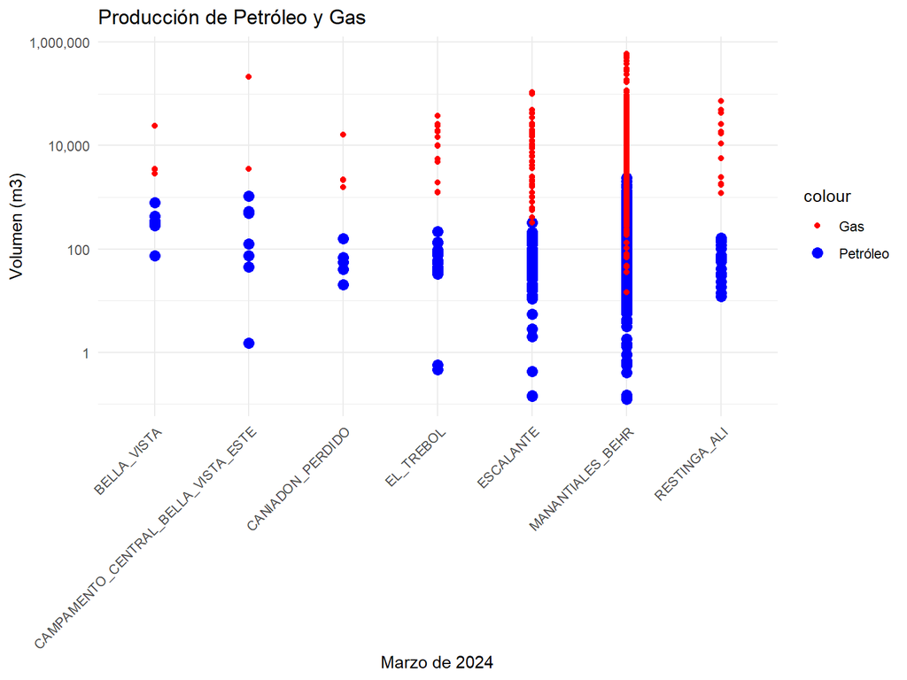

# Visualización de GOR para el mes de Marzo en yacimientos de Chubut

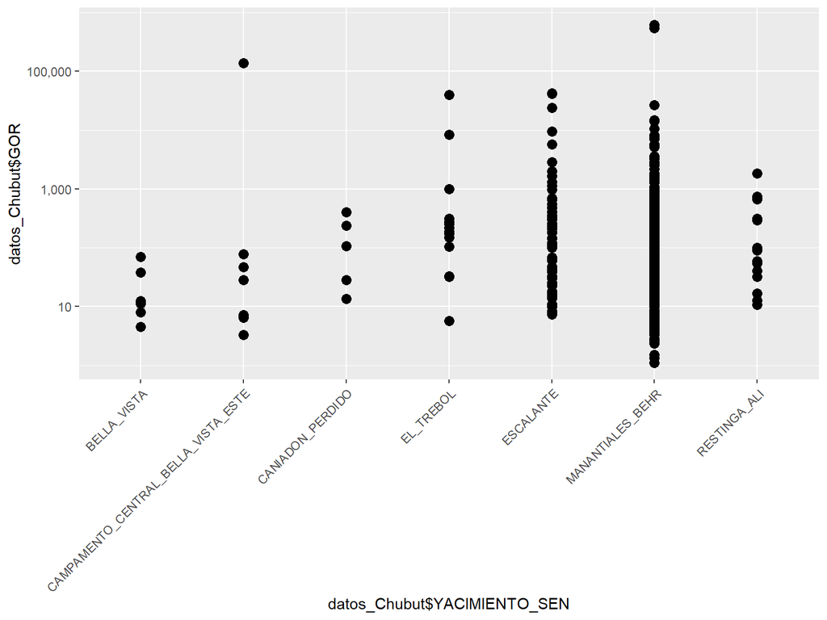